# Project: Movies Data Analysis - [tmbd_movies]

### Relationship between Popularity & Revenue

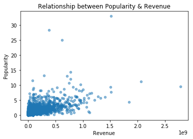

```python
df.plot.scatter(x="revenue", y="popularity", alpha=0.5)
plt.xlabel('Revenue');
plt.ylabel('Popularity');
plt.title('Relationship between Popularity & Revenue')
plt.show()
```

### Relationship between Budget & Revenue

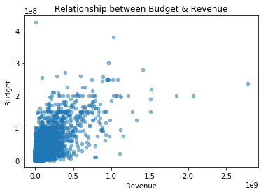

```python
df.plot.scatter(x="revenue", y="budget", alpha=0.5)
plt.xlabel('Revenue');
plt.ylabel('Budget');
plt.title('Relationship between Budget & Revenue')
plt.show()
```

Strong positive correllation between revenue and budget

### Relationship between Rating & Revenue

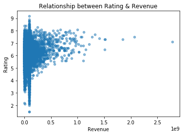

```python
df.plot.scatter(x="revenue", y="vote_average", alpha=0.5)
plt.xlabel('Revenue');
plt.ylabel('Rating');
plt.title('Relationship between Rating & Revenue')
plt.show()
```

Correllation between Revenue and Rating is not linear

### Relationship between Runtime & Popularity

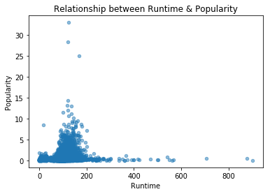

```python
df.plot.scatter(x="runtime", y="popularity", alpha=0.5)
plt.xlabel('Runtime');
plt.ylabel('Popularity');
plt.title('Relationship between Runtime & Popularity')
plt.show()
```

The correllation between Runtime and Popularity is low positive

### Correlation between Revenue and main metrics

Use get dummies to encode NaN values as their own dummy coded column using the dummy na option for categorical variables. In this cases genres. Split the column genres in 5 new columns and assuming that the first genre is the most accure to define the category of the movie

```python
# split genre column into 5 new columns to get the main one
df[['genre_0', 'genre_1','genre_2','genre_3','genre_4']] = df.genres.str.split("|", expand = True)
df_genres=dummy_cat(df, 'genre_0')
```

```python
df_genres.head()
```

|  | id | imdb_id | popularity | budget | revenue | original_title | cast | homepage | director | tagline | ... | History | Horror | Music | Mystery | Romance | Science Fiction | TV Movie | Thriller | War | Western |
| --- | --- | --- | --- | --- | --- | --- | --- | --- | --- | --- | --- | --- | --- | --- | --- | --- | --- | --- | --- | --- | --- |
| 0 | 135397 | tt0369610 | 32.985763 | 150000000.0 | 1.513529e+09 | Jurassic World | Chris Pratt\|Bryce Dallas Howard\|Irrfan Khan\|Vi... | http://www.jurassicworld.com/ | Colin Trevorrow | The park is open. | ... | 0 | 0 | 0 | 0 | 0 | 0 | 0 | 0 | 0 | 0 |
| 1 | 76341 | tt1392190 | 28.419936 | 150000000.0 | 3.784364e+08 | Mad Max: Fury Road | Tom Hardy\|Charlize Theron\|Hugh Keays-Byrne\|Nic... | http://www.madmaxmovie.com/ | George Miller | What a Lovely Day. | ... | 0 | 0 | 0 | 0 | 0 | 0 | 0 | 0 | 0 | 0 |
| 2 | 262500 | tt2908446 | 13.112507 | 110000000.0 | 2.952382e+08 | Insurgent | Shailene Woodley\|Theo James\|Kate Winslet\|Ansel... | http://www.thedivergentseries.movie/#insurgent | Robert Schwentke | One Choice Can Destroy You | ... | 0 | 0 | 0 | 0 | 0 | 0 | 0 | 0 | 0 | 0 |
| 3 | 140607 | tt2488496 | 11.173104 | 200000000.0 | 2.068178e+09 | Star Wars: The Force Awakens | Harrison Ford\|Mark Hamill\|Carrie Fisher\|Adam D... | http://www.starwars.com/films/star-wars-episod... | J.J. Abrams | Every generation has a story. | ... | 0 | 0 | 0 | 0 | 0 | 0 | 0 | 0 | 0 | 0 |
| 4 | 168259 | tt2820852 | 9.335014 | 190000000.0 | 1.506249e+09 | Furious 7 | Vin Diesel\|Paul Walker\|Jason Statham\|Michelle ... | http://www.furious7.com/ | James Wan | Vengeance Hits Home | ... | 0 | 0 | 0 | 0 | 0 | 0 | 0 | 0 | 0 | 0 |

5 rows × 48 columns

We need popularity related columns to find the correlection and predict the revenue.

```python
revenue_related_colms = [
            'budget', 'popularity', 'vote_count', 'vote_average', 'runtime',
            'Action','Adventure','Animation','Comedy', 'profit',
            'Crime','Documentary','Drama','Family','Fantasy','Foreign','History','Horror','Music',
            'Mystery','Romance','Science Fiction','TV Movie','Thriller','War','Western','revenue']# Official & Possible ML features
```

### Headmap

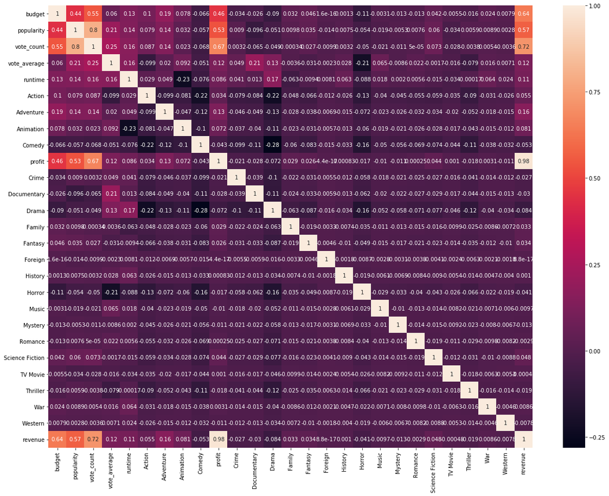

```python
# plt.figure(dpi=3000)
plt.figure(figsize = (20,15))
sns.heatmap(df_genres[revenue_related_colms].corr(), cmap="rocket", annot=True, annot_kws={"fontsize": 10});
```

### Does the Director affect to the Popularity

```python
#Most popular directors
value = df.groupby(["director"])['popularity'].sum()
value.sort_values(ascending = False)
```

```
director
Christopher Nolan                   61.955206
Steven Spielberg                    54.378995
Peter Jackson                       49.067904
Ridley Scott                        46.213770
Quentin Tarantino                   46.059995
George Miller                       35.600006
Tim Burton                          34.648225
David Fincher                       34.479784
Robert Zemeckis                     33.619667
Colin Trevorrow                     33.393773
Martin Scorsese                     32.727880
Chris Columbus                      31.514525
James Cameron                       29.098111
Ron Howard                          28.500979
Clint Eastwood                      28.221269
Francis Lawrence                    26.625627
Woody Allen                         25.354086
J.J. Abrams                         24.004784
George Lucas                        23.461834
Michael Bay                         22.254874
Gore Verbinski                      22.075374
David Yates                         20.815974
Steven Soderbergh                   20.793033
Francis Ford Coppola                20.268024
Alejandro GonzÃ¡lez IÃ±Ã¡rritu      19.174145
Jon Favreau                         19.105071
Antoine Fuqua                       18.827364
Sam Mendes                          18.714189
Shawn Levy                          18.442591
Roland Emmerich                     18.265585
                                      ...
Zak Levitt                           0.004575
Ricki Stern|Anne Sundberg            0.004569
Venus Keung Kwok-Man|Wong Jing       0.004433
Connor McGuire|Colin McGuire         0.004323
Shashank Khaitan                     0.004282
Alex Holdridge                       0.004196
Karen Disher|Guy Moore               0.004010
Laurent Malaquais                    0.003611
```

[output cut: 8 more lines]

```
Barbara Schroeder                    0.002460
Charles B. Pierce                    0.002381
Norman Buckley                       0.002262
Beth McCarthy-Miller|Rob Ashford     0.002165
Amol Palekar                         0.001983
Sarah Burns|Ken Burns                0.001783
Enrico Oldoini                       0.001567
Russ Malkin|David Alexanian          0.001531
Stephen Cragg                        0.001423
Nacho G. Velilla                     0.001317
Jean-Xavier de Lestrade              0.001315
Zana Briski|Ross Kauffman            0.001117
Dibakar Banerjee                     0.001115
Pascal Thomas                        0.000973
Name: popularity, Length: 5067, dtype: float64
```

```python
#Most popular directors
value = df.groupby(["director"])['revenue'].sum()
value.sort_values(ascending = False)
```

```
director
Steven Spielberg                                                                            9.197005e+09
Peter Jackson                                                                               6.701686e+09
James Cameron                                                                               6.020336e+09
Michael Bay                                                                                 4.917208e+09
Christopher Nolan                                                                           4.345990e+09
David Yates                                                                                 4.243516e+09
Robert Zemeckis                                                                             4.048132e+09
Chris Columbus                                                                              4.029933e+09
Tim Burton                                                                                  3.933077e+09
Ron Howard                                                                                  3.841354e+09
Ridley Scott                                                                                3.739217e+09
J.J. Abrams                                                                                 3.579170e+09
Roland Emmerich                                                                             3.571767e+09
Sam Raimi                                                                                   3.550703e+09
Gore Verbinski                                                                              3.548780e+09
Clint Eastwood                                                                              3.538637e+09
George Lucas                                                                                3.316551e+09
Francis Lawrence                                                                            3.179980e+09
Joss Whedon                                                                                 3.052684e+09
Martin Scorsese                                                                             2.948673e+09
Woody Allen                                                                                 2.904100e+09
Sam Mendes                                                                                  2.713549e+09
Carlos Saldanha                                                                             2.621672e+09
Steven Soderbergh                                                                           2.605485e+09
M. Night Shyamalan                                                                          2.452355e+09
Barry Sonnenfeld                                                                            2.340032e+09
Shawn Levy                                                                                  2.307808e+09
James Wan                                                                                   2.242804e+09
David Fincher                                                                               2.139346e+09
Tony Scott                                                                                  2.129613e+09
                                                                                                ...
David Brooks                                                                                3.010000e+03
Stephen Elliott                                                                             3.003000e+03
Nacho Vigalondo|Marcel Sarmiento|Gregg Bishop|Justin Benson|Aaron Moorhead|Todd Lincoln     2.756000e+03
Matthew A. Brown                                                                            2.710000e+03
David Weaver                                                                                2.521000e+03
Ted Koland                                                                                  1.938000e+03
Boris Rodriguez                                                                             1.632000e+03
Dermot Mulroney                                                                             1.378000e+03
```

[output cut: 8 more lines]

```
John Ridley                                                                                 9.700000e+01
Don Hahn                                                                                    8.000000e+01
Michael Pressman                                                                            7.800000e+01
Alek Keshishian|Mark Aldo Miceli                                                            2.900000e+01
Gene Quintano                                                                               2.700000e+01
Joseph Barbera|William Hanna                                                                2.000000e+01
Gregory Widen                                                                               1.600000e+01
Adam Marcus                                                                                 1.500000e+01
Ate de Jong                                                                                 1.300000e+01
Rusty Cundieff                                                                              1.100000e+01
Benedikt Erlingsson                                                                         1.100000e+01
Silvio Muccino                                                                              9.000000e+00
Peter Hall                                                                                  6.000000e+00
Gilbert Adler                                                                               5.000000e+00
Name: revenue, Length: 5067, dtype: float64
```